# lab_deliverable_2

Yihang Duanmu, Minjun Kim, Annelise Schreiber

2025-10-01

```r
library(tidyverse); library(broom); library(kableExtra); library(here); library(janitor); library(lubridate); library(readr); library(dplyr); library(emmeans); library(ggplot2)
```

First, install the necessary packages.

```r
fb_raw <- readr::read_delim("dataset_Facebook.csv", delim = ";", show_col_types = FALSE)

fb <- fb_raw |>
  janitor::clean_names() |>
  mutate(
    post_month   = suppressWarnings(as.integer(post_month)),
    post_weekday = suppressWarnings(as.integer(post_weekday)),
    post_hour    = suppressWarnings(as.integer(post_hour)),
    paid         = if_else(is.na(paid), 0L, as.integer(paid)),
    lifetime_post_consumers = as.numeric(lifetime_post_consumers)
  )
```

Load the csv file and standardize the column names.

```r
fb2 <- fb |>
  mutate(
    post_weekday_num = post_weekday,
    post_hour_num    = post_hour,
    post_month_num   = post_month
  )

# Weekday factor (1–7 expected)
wk_labels <- c("Mon","Tue","Wed","Thu","Fri","Sat","Sun")
if (all(!is.na(fb2$post_weekday_num)) && all(fb2$post_weekday_num %in% 1:7)) {
  wday_fac <- factor(fb2$post_weekday_num, levels = 1:7, labels = wk_labels, ordered = TRUE)
} else {
  # fallback if strings slipped through
  wday_fac <- factor(as.character(fb$post_weekday), ordered = TRUE)
}

# Hour factor: detect actual range (handles 0–23 or 1–23)
hour_levels <- sort(unique(fb2$post_hour_num[!is.na(fb2$post_hour_num)]))
hour_fac <- factor(fb2$post_hour_num, levels = hour_levels, ordered = TRUE)

# Month factor (1–12 -> Jan..Dec)
if (all(!is.na(fb2$post_month_num)) && all(fb2$post_month_num %in% 1:12)) {
  month_fac <- factor(fb2$post_month_num, levels = 1:12, labels = month.abb, ordered = TRUE)
} else {
  month_fac <- factor(fb$post_month, ordered = TRUE)
}

# Paid flag as tidy factor
paid_fac <- factor(if_else(is.na(fb$paid) | fb$paid == 0, "Unpaid", "Paid"),
                   levels = c("Unpaid","Paid"))
```

This block standardizes your time and paid fields for modeling. First, it builds fb2 by safely coercing post_weekday, post_hour, and post_month to integers (silently turning non-numeric text into NA). Then it creates ordered factors: wday_fac maps weekday codes (or text like “Monday”) to “Mon”–“Sun”; hour_fac turns hours into an ordered 0–23 factor; and month_fac maps 1–12 to “Jan”–“Dec” (or falls back to whatever strings exist).

```r
dat <- tibble(
  consumers = fb$lifetime_post_consumers,
  paid = paid_fac,
  wday = wday_fac,
  hour= hour_fac,
  month = month_fac,
  idx = seq_len(nrow(fb))
)

summary(dat$consumers)
```

```
##    Min. 1st Qu.  Median    Mean 3rd Qu.    Max.
##     9.0   332.5   551.5   798.8   955.5 11328.0
```

This code builds the analysis tibble dat—it picks the response (consumers) and the cleaned timing predictors (wday, hour, month), adds the promotion flag (paid), and creates a simple time-order index (idx). The summary(dat$consumers) line quickly checks the outcome’s distribution; the output (min 9, Q1 ≈ 333, median ≈ 552, mean ≈ 799, Q3 ≈ 956, max ≈ 11,328) shows a right-skewed variable with large upper outliers, which motivates options like log1p(consumers) or robust SEs in later models.

Question 1: Does the date and time in which a post is made impact the engagement that said post receives?

We used log1p(consumers) because engagement counts are extremely right-skewed with a few huge outliers, which compresses most points near zero on the raw scale and can overly influence the fit.

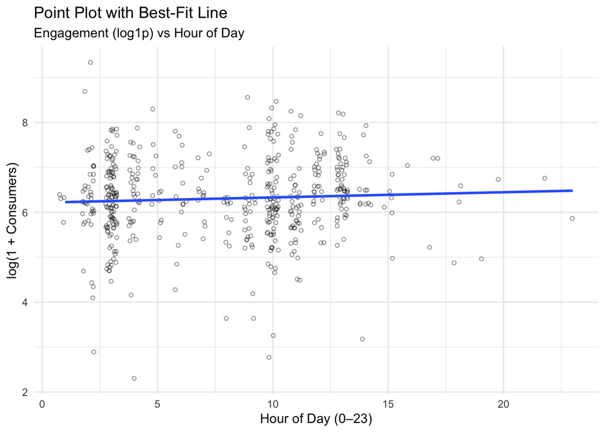

```r
plot_df <- dat |> mutate(hour_num = as.numeric(as.character(hour)))

ggplot(plot_df, aes(x = hour_num, y = log1p(consumers))) +
  geom_point(shape = 1, alpha = 0.45, size = 1.2, position = position_jitter(width = 0.25, height = 0)) +
  geom_smooth(method = "lm", se = FALSE) +
  labs(title = "Point Plot with Best-Fit Line",
       subtitle = "Engagement (log1p) vs Hour of Day",
       x = "Hour of Day (0–23)", y = "log(1 + Consumers)") +
  theme_minimal()
```

The point plot of log1p(consumers) vs hour shows a very slight upward slope, indicating a weak tendency for engagement to be higher at later hours.

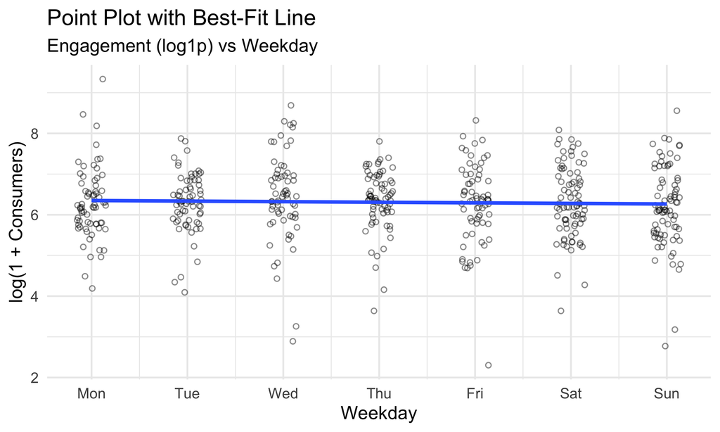

```r
wk_map <- setNames(1:7, c("Mon","Tue","Wed","Thu","Fri","Sat","Sun"))
plot_df2 <- dat |> mutate(wday_num = unname(wk_map[as.character(wday)]))

ggplot(plot_df2, aes(x = wday_num, y = log1p(consumers))) +
  geom_point(shape = 1, alpha = 0.45, size = 1.2, position = position_jitter(width = 0.15, height = 0)) +
  geom_smooth(method = "lm", se = FALSE) +
  scale_x_continuous(breaks = 1:7, labels = names(wk_map)) +
  labs(title = "Point Plot with Best-Fit Line",
       subtitle = "Engagement (log1p) vs Weekday",
       x = "Weekday", y = "log(1 + Consumers)") +
  theme_minimal()
```

The point plot of log1p(consumers) by weekday shows an almost flat best-fit line, with similar clouds of points for Mon–Sun.